# Raport

# Regresor

Do stworzenia regresora została wykorzystana metoda Random Forest, jako metryka błedu został wykorzystany RMSE - czyli błąd średniokwadratowy. Ilosć drzew została ustawiona na podstawie eksperymentów na 20.

Dane zostały podzielone na 2 zbiory: zbiór treningowy - zawierający 80 % danych, oraz zbiór testowy - zawierający 20 %

```r
afterFeatureSelection <- df_no_na %>% select(length, cfin1, cfin2, chel1, chel2, lcop1, lcop2, fbar, recr, cumf, totaln, sst, sal, nao)

inTraining <- createDataPartition(y=afterFeatureSelection$length,p=0.8,list = F)
training <- afterFeatureSelection[inTraining,]
testing <- afterFeatureSelection[-inTraining,]
X_train = select(training, -length)
y_train = training$length
X_test = select(testing, -length)
y_test = testing$length
```

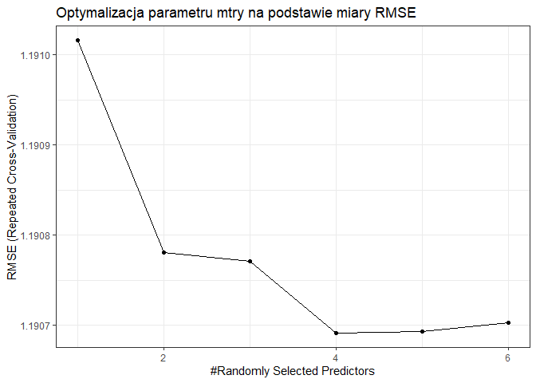

```r
fit <- train(X_train,y_train,
            method = 'rf',
             trControl = ctrl,
             metric = "RMSE",
             tuneGrid=rfGrid,
             importance = TRUE,
             ntree=20)
ggplot(fit) + ggtitle("Optymalizacja parametru mtry na podstawie miary RMSE") + theme_bw()
```

Sprawdzenie modelu na danych testowych

```r
predictions <- predict(fit, newdata = X_test)
modelValues <- data.frame(obs = y_test, pred = predictions)
kable(fit$results, caption = "Tabela wyników z podzbioru uczącego")
```

Tabela wyników z podzbioru uczącego

| mtry | RMSE | Rsquared | MAE | RMSESD | RsquaredSD | MAESD |
| --- | --- | --- | --- | --- | --- | --- |
| 1 | 1.191016 | 0.4814546 | 0.9408527 | 0.0088770 | 0.0070564 | 0.0066071 |
| 2 | 1.190781 | 0.4816634 | 0.9405444 | 0.0088491 | 0.0071403 | 0.0065099 |
| 3 | 1.190771 | 0.4816592 | 0.9405148 | 0.0088704 | 0.0070689 | 0.0064455 |
| 4 | 1.190692 | 0.4817293 | 0.9404672 | 0.0089877 | 0.0071602 | 0.0064862 |
| 5 | 1.190693 | 0.4817204 | 0.9402680 | 0.0088012 | 0.0071579 | 0.0063432 |
| 6 | 1.190703 | 0.4817234 | 0.9402743 | 0.0089912 | 0.0072815 | 0.0065609 |

Model regresyjny został poddany testom na danych testowych. Osiągnięto wynik w postaci miar RMSE i Rsquared:

|  | x |
| --- | --- |
| RMSE | 1.1774105 |
| Rsquared | 0.4801605 |
| MAE | 0.9356735 |

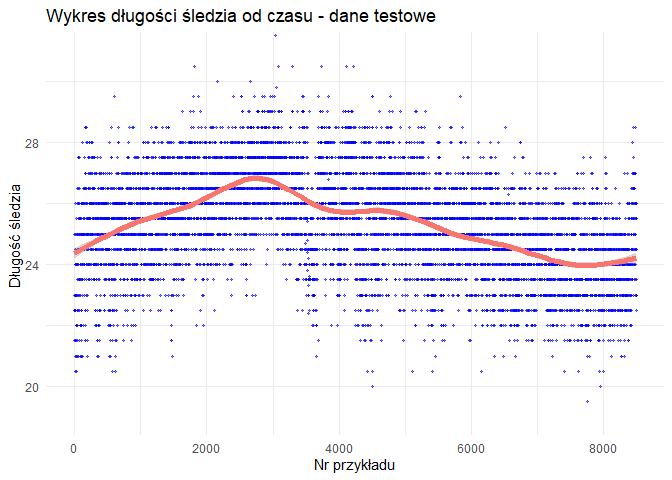

```r
xs <- 1:length(y_test)
dataf <- data.frame(xs,y_test)
reg_plot_test <- ggplot(dataf,aes(dataf$xs,dataf$y_test)) +
  geom_point(alpha = 0.5, size = 0.7,color="blue") +
  geom_smooth(aes(y=dataf$y_test,colour = "trend"), size = 2) +
  coord_cartesian(ylim = c(19, 31)) +
  theme_minimal() + theme(legend.position = "none") +
  labs(x = "Nr przykładu", y = "Długość śledzia ") +
  ggtitle("Wykres długości śledzia od czasu - dane testowe")
reg_plot_test
```

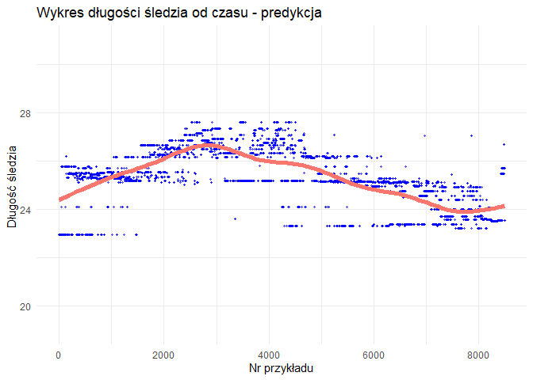

```r
xs <- 1:length(predictions)
dataf <- data.frame(xs,predictions)
reg_plot_test <- ggplot(dataf,aes(dataf$xs,dataf$predictions)) +
  geom_point(alpha = 0.5, size = 0.7,color="blue") +
  geom_smooth(aes(y=dataf$predictions,colour = "trend"), size = 2) +
  coord_cartesian(ylim = c(19, 31)) +
  theme_minimal() + theme(legend.position = "none") +
  labs(x = "Nr przykładu", y = "Długość śledzia ") +
  ggtitle("Wykres długości śledzia od czasu - predykcja")
reg_plot_test
```

# Analiza ważności atrybutów

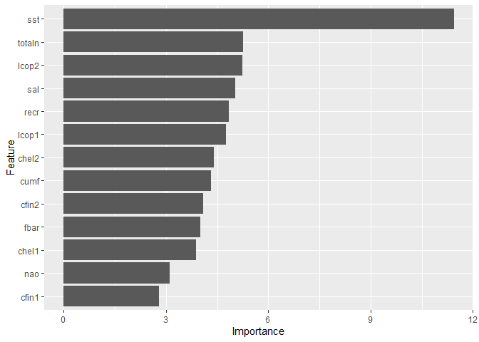

```r
importance <- varImp(fit, scale = FALSE)
ggplot(importance)
```

Z wykresu wynika, że najważniejszym atrybutem jest sst - temperatura przy powierzchni wody. Jego dominacja nad pozostałymi atrybutmami jest dość znacząca. Na drugim miejscu znajduje się totaln oraz lcop2, czyli liczość połowów oraz dostępność planktonu - zagęszczenie widłonogów gat. 2. Co ciekawe żadne z tych atrybutów nie miały znacząjek korelacji między sobą.

## Zależność długości śledzia od temperatury przy powiechni

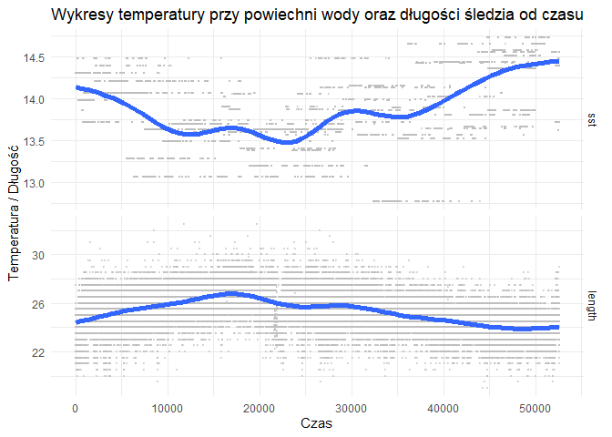

```r
df_sst_length <- df_no_na %>% select(X,sst,length)
df_sst_length2 <- melt(df_sst_length,id.vars = 'X')
fin_plot_tlen <- ggplot(df_sst_length2,aes(x = X, y=value)) +
  geom_point(size = 0.5, alpha = 0.5, color="grey") +
  geom_smooth(size = 2) +
  facet_grid(variable~. ,scales = 'free')  + theme_minimal() +
  labs(x = "Czas", y = "Temperatura / Długość") +
  scale_x_continuous() +
  ggtitle("Wykresy temperatury przy powiechni wody oraz długości śledzia od czasu")
fin_plot_tlen
```

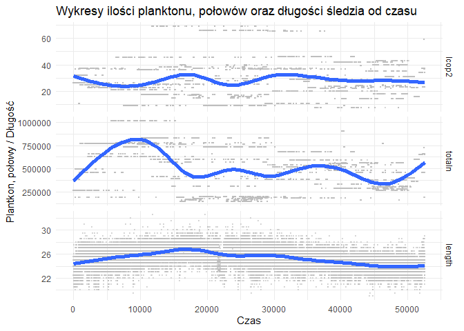

```r
df_planct <- df_no_na %>% select(X,lcop2,totaln,length)
df_planct2 <- melt(df_planct,id.vars = 'X')
fin_plot_tlen <- ggplot(df_planct2,aes(x = X, y=value)) +
  geom_point(size = 0.5, alpha = 0.5, color="grey") +
  geom_smooth(size = 2) +
  facet_grid(variable~. ,scales = 'free')  + theme_minimal() +
  labs(x = "Czas", y = "Plantkon, połowy / Długość") +
  scale_x_continuous() +
  ggtitle("Wykresy ilości planktonu, połowów oraz długości śledzia od czasu")
fin_plot_tlen
```

# Wnioski

# Interaktywny Wykres

W celu wygenerowania interaktywnego wykresu za pomocą biblioteki shiny, dane z kolumny lenght zostały pogrupowane po 50 kolejnych elementów, a z takich grup policzona średnia. Wykonano to by “suwak” na wykresie nie był za długi. Niestety biblioteka shiny nie daje możliwości na wykorzystanie jej w statycznym pliku raportu, dlatego kod do wykonania takiego wykresu znajduje się w pliku “library.R”.